# Differential Mapping BXDspecific vs B6 mm10 (permissive mapping setting)

Nastassia Gobet, Maxime Jan

12 February 2021

# GOAL

Perform differential expression-like analysis, expect that to compare mapping on BXD-specific references or B6 mm10 primary reference (refered after as B6). Differential mapping (DM) analysis.

# DATA

## References

The sequences (.fasta) and annotations (.gtf) are taken from Ensembl (http://www.ensembl.org/Mus_musculus/Info/Index), release 94 for B6 mm10. To do the BXD-specific references, it was modified with GN mm10 genotypes and SNVs and indels D2-specific from dbSNP (imputed genotypes with D2 blocks method).

For B6, automatic based on experimental evidence (ensembl) and manual (havana) annotation (http://www.ensembl.org/info/genome/genebuild/genome_annotation.html). The 2 annotation types are merged, and genes supported by the 2 are grouped as the GENECODE set for mouse (https://www.gencodegenes.org/). Gene names come from here (http://www.informatics.jax.org/).

## Mapping parameters

We use permissive (STAR default) mapping parameters:

- use of transcriptome annotation for junctions
- splicing (de novo) allowed
- trimming allowed (soft-clipping)
- up to 10 mismatches (for reads of 100 bp)

(genotypesandimputed_withannotation_Local_0_10)

## gene expression table

The input data are raw counts of gene expression (counted per sample by ht-count, then grouped). Rows are genes and columns are libraries/samples. (One library per sample, no replicate). Samples are lines + condition (SD or NSD).

### Loading

```r
# Import the raw counts table for counts mapped on BXD-specific references
countsBXD <- read.table("F:/BXD/data/MappingEvaluation/genotypesandimputed_withannotation_Local_0_10/Summary_ReadsPerGene.out.tab", header=TRUE, row.names=1, stringsAsFactors=FALSE)
# Import the raw counts table for counts mapped on B6
countsB6 <- read.table("F:/BXD/data/transcriptome/2_mapping_STAR/OnGenomeAndAnnotation/B6mm10primaryassembly_withannotation/Summary_ReadsPerGene.out.tab", header=TRUE, row.names=1, stringsAsFactors=FALSE)

# change X into C (for cortex) in colnames
colnames(countsBXD) <- gsub("X","C", colnames(countsBXD))
colnames(countsB6) <- gsub("X","C", colnames(countsB6))
```

There are 132 libraries and 54397 genes in BXD counts. There are 132 libraries and 54532 genes in B6 counts.

### Dealing with gene names

Convert geneID into gene names, remove duplicate gene names, keep only gene names common to BXD and B6.

```r
B6mm10geneConvert <- read.table("F:/BXD/references/gene_names_B6mm10.tab", header=FALSE, stringsAsFactors=FALSE, sep="\t")
colnames(B6mm10geneConvert) <- c("GeneID", "GeneName")
# remove B6 replicate gene names
B6mm10geneConvert <- B6mm10geneConvert[-which(!isUnique(B6mm10geneConvert$GeneName)),]
rownames(B6mm10geneConvert) <- 1:nrow(B6mm10geneConvert)
### could be improved by adding the counts from different transcripts

# try to find B6 matching names
idx <- na.omit(match(rownames(countsB6),B6mm10geneConvert$GeneID))
# take B6 subset
countsB6 <- countsB6[B6mm10geneConvert$GeneID[idx],]

# convert B6 rownames (GeneID) into gene name
rownames(countsB6) <- B6mm10geneConvert$GeneName[idx]

# try to find BXD matching names
idx <- na.omit(match(rownames(countsBXD),B6mm10geneConvert$GeneID))
# take BXD subset
countsBXD <- countsBXD[B6mm10geneConvert$GeneID[idx],]

# convert BXD rownames (GeneID) into gene name
rownames(countsBXD) <- B6mm10geneConvert$GeneName[idx]

# find which genes are common between B6 and BXD
commongenes <- intersect(rownames(countsBXD), rownames(countsBXD))
# get back geneID of common genes
any(is.na(match(commongenes, B6mm10geneConvert$GeneName)))
```

```
## [1] FALSE
```

```r
any(is.na(match(commongenes, B6mm10geneConvert$GeneName)))
```

```
## [1] FALSE
```

```r
commongenesB6id <- B6mm10geneConvert$GeneID[match(commongenes, B6mm10geneConvert$GeneName)]
commongenesBXDid <- B6mm10geneConvert$GeneID[match(commongenes, B6mm10geneConvert$GeneName)]
# save common gene names
write.table(commongenes, file="F:/BXD/data/transcriptome/3_counting_htseq/OnGenomeAndAnnotation/commongenes.txt", col.names=FALSE, row.names=FALSE, quote=FALSE)
# save common genes names B6 id
write.table(commongenesB6id, file="F:/BXD/data/transcriptome/3_counting_htseq/OnGenomeAndAnnotation/commongenesB6id.txt", col.names=FALSE, row.names=FALSE, quote=FALSE)
# save common genes names BXD id
write.table(commongenesBXDid, file="F:/BXD/data/transcriptome/3_counting_htseq/OnGenomeAndAnnotation/commongenesBXDid.txt", col.names=FALSE, row.names=FALSE, quote=FALSE)

# keep only genes in common between B6 and BXD (and ensure that rownames is the same in both dataset)
countsBXD <- countsBXD[commongenes,]
countsB6 <- countsB6[commongenes,]
```

There are 54204 genes in BXD counts and 54204 genes in B6 counts.

### Splitting

Splitting between tissue (cortex and liver)

```r
# add mapping reference in column names
colnames(countsBXD) <- paste(colnames(countsBXD), "BXD", sep="_")
colnames(countsB6) <- paste(colnames(countsB6), "B6", sep="_")

# separate tissue instead of mapping reference
countsCortex <- cbind(countsBXD[,grep("C", colnames(countsBXD))], countsB6[,grep("C", colnames(countsB6))])
countsLiver <- cbind(countsBXD[,grep("L", colnames(countsBXD))],countsB6[,grep("L", colnames(countsB6))])
```

# Analysis

## Filtering

We want to filter the expression data to take only gene with average expression above 10. This is an arbitrary threshold to remove genes that are of low abundance, more likely to be noisy.

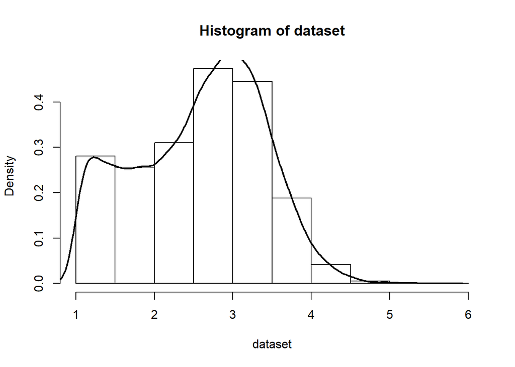

```r
# create a subset of the count table, filtering out rows (genes) with average counts <= 10
countsCortex <- countsCortex[which(apply(countsCortex, MARGIN=1, FUN=mean)>10),]
countsLiver <- countsLiver[which(apply(countsLiver, MARGIN=1, FUN=mean)>10),]

# create a function that plots the histogram + density curve
plotHistDensity <- function(dataset){
  hist(dataset, freq=FALSE)
  lines(density(dataset), lwd=2)
}
##plotHistDensity(rnorm(10000))
##par(mfrow=c(1,2))
plotHistDensity(log10(unlist(apply(countsCortex, MARGIN=1, FUN=mean))))
```

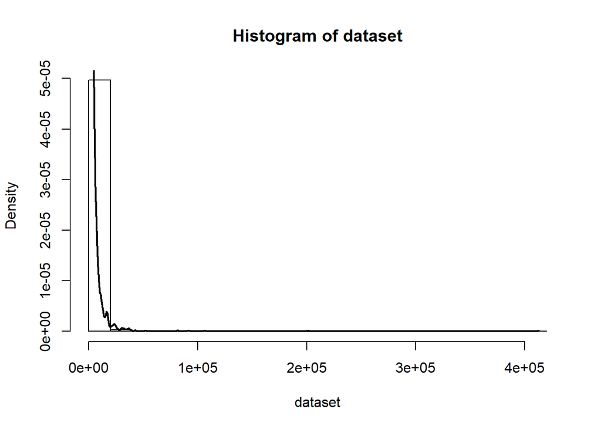

```r
plotHistDensity(unlist(apply(countsCortex, MARGIN=1, FUN=mean)))
```

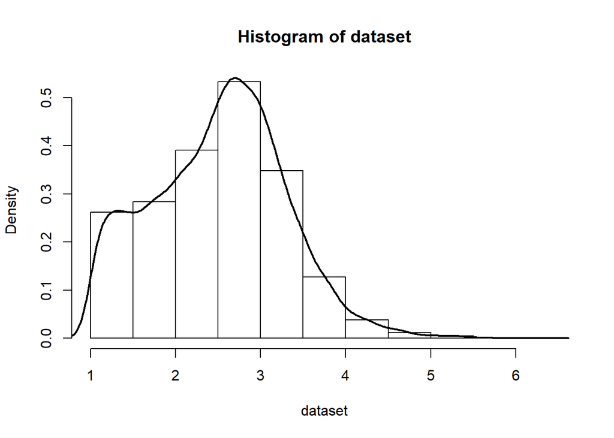

```r
plotHistDensity(log10(unlist(apply(countsLiver, MARGIN=1, FUN=mean))))
```

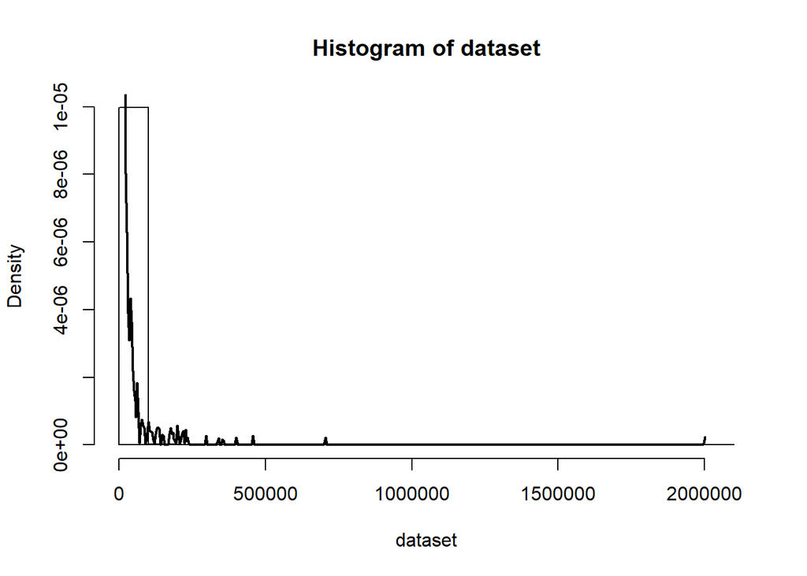

```r
plotHistDensity(unlist(apply(countsLiver, MARGIN=1, FUN=mean)))
```

The filtered datasets have 16788 genes in cortex and 13144 genes in liver.

## Standarization

The normalization is performed using the Weighted trimmed mean of M-values (TMM) method of the edgeR package. This step standarizes the counts gene expression to take into account the variation in library size (=number of counts per library), the variation in length of the transcripts, and in RNA population variation. (Robinson, Genome Biology, 2010).

```r
# formatting for edgeR (creates a DGEList object from the dataframe)
dC <- DGEList(counts=countsCortex)
dL <- DGEList(counts=countsLiver)

# calculate the normalization factors for each sample TMM method (effective library size)
dC <- calcNormFactors(dC, method="TMM")
dL <- calcNormFactors(dL, method="TMM")

# calculate CPM and normalize the counts
normalizedCPMcountsCortex <- data.frame(cpm(dC, normalized.lib.sizes=TRUE))
normalizedCPMcountsLiver <- data.frame(cpm(dL, normalized.lib.sizes=TRUE))

# Export normalized CPM
write.table(normalizedCPMcountsCortex, file="F:/BXD/data/transcriptome/4_normalization/BXDB6permissive_edgeRTMMnormalized_CPM_Cortex.tab", row.names=TRUE, sep="\t", quote=FALSE)
write.table(normalizedCPMcountsLiver, file="F:/BXD/data/transcriptome/4_normalization/BXDB6permissive_edgeRTMMnormalized_CPM_Liver.tab", row.names=TRUE, sep="\t", quote=FALSE)
```

## Differential gene mapping

Find which genes appear up- or down-regulated if mapping on reference rather than the other.

This is done here using voom from limma package.

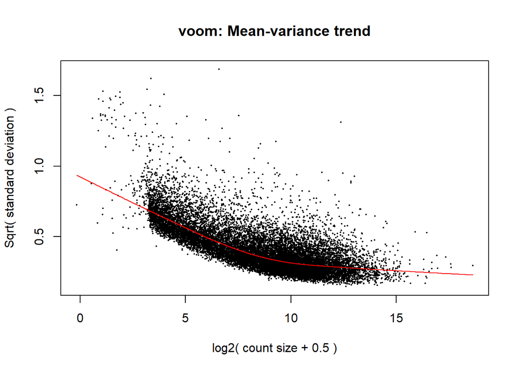

```r
# prepare the design
variables <- matrix(unlist(strsplit(colnames(normalizedCPMcountsCortex), "_")), ncol=2, byrow=TRUE)
colnames(variables) <- c("samplename","mappingref")
strains <- factor(gsub("[Cnsd]","",variables[,"samplename"]))
design <- model.matrix(~strains+factor(variables[,"mappingref"]))

# by default the normalization method is quantile (voom calls normalizeBetweenArrays)
# plot the mean-variance trend
##res <- voom(countsCortex, design, plot=TRUE, lib.size=colSums(countsCortex)*dC$samples$norm.factors)
resC <- voom(dC, design, plot=TRUE)
```

```r
resCortexNorm <- resC$E

# fitting
# fit the coefficient of the linear model
fitC <- lmFit(resC, design)
# calculates the t-statistics
fitC2 <- eBayes(fitC)

# write all results
resultTable <- topTable(fitC2, coef=ncol(fitC$coefficients), adjust="fdr", sort.by="B", number=1000000)
# sort by adjusted p-value
resultTable <- resultTable[order(resultTable$adj.P.Val),]

# store information about DE analysis
write.table(resultTable, file="F:/BXD/data/transcriptome/5_DifferentialMapping/DifferentialMappingBXDvsB6mm10permissive_Limma_Cortex.txt", row.names=TRUE, sep="\t", quote=FALSE)
```

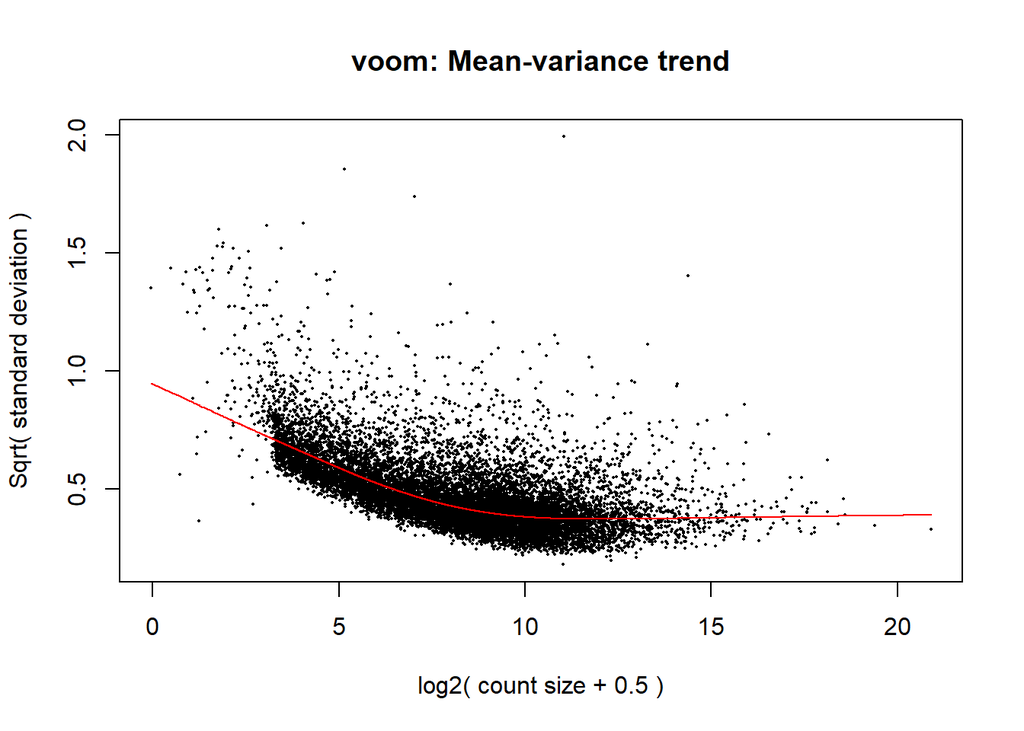

```r
# prepare the design
variables <- matrix(unlist(strsplit(colnames(normalizedCPMcountsLiver), "_")), ncol=2, byrow=TRUE)
colnames(variables) <- c("samplename","mappingref")
strains <- factor(gsub("[Cnsd]","",variables[,"samplename"]))
design <- model.matrix(~strains+factor(variables[,"mappingref"]))

# by default the normalization method is quantile (voom calls normalizeBetweenArrays)
# plot the mean-variance trend
##res <- voom(countsLiver, design, plot=TRUE, lib.size=colSums(countsLiver)*dL$samples$norm.factors)
resL <- voom(dL, design, plot=TRUE)
```

```r
resLiverNorm <- resL$E

# fitting
# fit the coefficient of the linear model
fitL <- lmFit(resL, design)
# calculates the t-statistics
fitL2 <- eBayes(fitL)

# write all results
resultTable <- topTable(fitL2, coef=ncol(fitL$coefficients), adjust="fdr", sort.by="B", number=1000000)
# sort by adjusted p-value
resultTable <- resultTable[order(resultTable$adj.P.Val),]

# store information about DE analysis
write.table(resultTable, file="F:/BXD/data/transcriptome/5_DifferentialMapping/DifferentialMappingBXDvsB6mm10permissive_Limma_Liver.txt", row.names=TRUE, sep="\t", quote=FALSE)
```

# Plotting results

Volcano plots

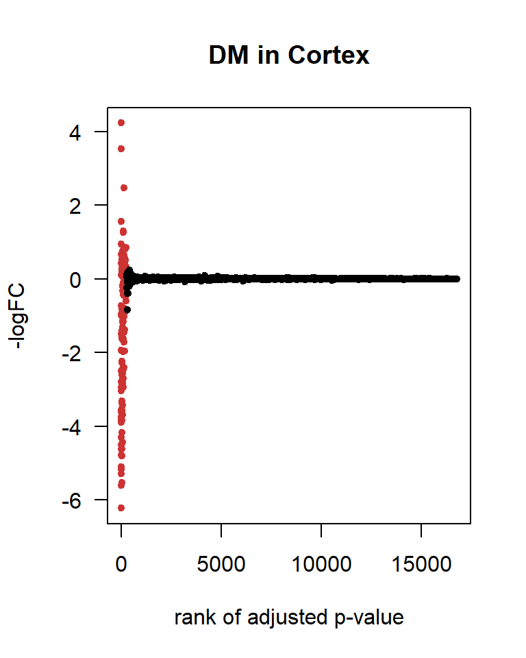

```r
# load table with results of differential expression
DMdata_Cortex <- read.table('F:/BXD/data/transcriptome/5_DifferentialMapping/DifferentialMappingBXDvsB6mm10permissive_Limma_Cortex.txt', sep="\t")
DMdata_Liver <- read.table('F:/BXD/data/transcriptome/5_DifferentialMapping/DifferentialMappingBXDvsB6mm10permissive_Limma_Liver.txt', sep="\t")

# volcano plot all transcripts in black and significant in red
# set the colors
palette(c("black", "brown3"))

# plot for Cortex
plot(1:nrow(DMdata_Cortex), DMdata_Cortex$logFC, las=1, pch=20, col=as.factor(DMdata_Cortex$adj.P.Val<=0.05),
       main="DM in Cortex", xlab="rank of adjusted p-value", ylab="-logFC")
```

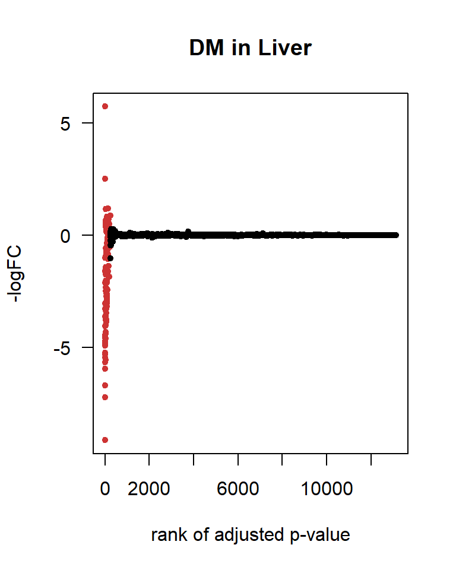

```r
# plot for Liver
plot(1:nrow(DMdata_Liver), DMdata_Liver$logFC, las=1, pch=20, col=as.factor(DMdata_Liver$adj.P.Val<=0.05),
       main="DM in Liver", xlab="rank of adjusted p-value", ylab="-logFC")
```

The -logFC represents ratio of BXD over B6 (positive values map better on BXD, negative values map better on B6).

2% of genes are significantly (below or equal to 0.05) differentially mapped in cortex, and 2% in liver.

```r
# get top 5 up- and top 5 down-measured genes
DMdata_Cortex <- DMdata_Cortex[order(DMdata_Cortex$logFC),]
head(DMdata_Cortex,5)
```

|  | logFC | AveExpr | t | P.Value | adj.P.Val | B |
| --- | --- | --- | --- | --- | --- | --- |
| Gm8730 | -6.218444 | -1.5817827 | -19.20268 | 1.634513e-35 | 2.110786e-32 | 69.61030 |
| Gm13394 | -5.594477 | 0.3028892 | -26.21666 | 6.637281e-47 | 5.406959e-43 | 96.40755 |
| Gm10260 | -5.530421 | -3.0604859 | -13.96442 | 2.456521e-25 | 1.249699e-22 | 46.91390 |
| Rps15a-ps8 | -5.279457 | -3.3146367 | -15.61681 | 1.046743e-28 | 8.786358e-26 | 53.78639 |
| Gm6166 | -5.167123 | -1.7724451 | -23.46663 | 1.020241e-42 | 3.425562e-39 | 85.97028 |

```r
print(head(DMdata_Cortex[,c("logFC","adj.P.Val")],5))
```

```
##                logFC    adj.P.Val
## Gm8730     -6.218444 2.110786e-32
## Gm13394    -5.594477 5.406959e-43
## Gm10260    -5.530421 1.249699e-22
## Rps15a-ps8 -5.279457 8.786358e-26
## Gm6166     -5.167123 3.425562e-39
```

```r
tail(DMdata_Cortex,5)
```

|  | logFC | AveExpr | t | P.Value | adj.P.Val | B |
| --- | --- | --- | --- | --- | --- | --- |
| Gm12966 | 1.293215 | -1.377328 | 7.933219 | 2.976322e-12 | 4.129462e-10 | 17.48972 |
| Gm12394 | 1.566166 | -1.419959 | 19.665831 | 2.429132e-36 | 3.398356e-33 | 71.55580 |
| Gm17383 | 2.478949 | -3.550628 | 6.850475 | 5.855779e-10 | 6.301719e-08 | 12.43680 |
| Gm20878 | 3.530082 | -1.599350 | 30.176285 | 2.176657e-52 | 3.654171e-48 | 105.07730 |
| Rpl5-ps2 | 4.231204 | -3.554902 | 14.610031 | 1.139325e-26 | 6.595515e-24 | 49.22743 |

```r
print(tail(DMdata_Cortex[,c("logFC","adj.P.Val")],5))
```

```
##             logFC    adj.P.Val
## Gm12966  1.293215 4.129462e-10
## Gm12394  1.566166 3.398356e-33
## Gm17383  2.478949 6.301719e-08
## Gm20878  3.530082 3.654171e-48
## Rpl5-ps2 4.231204 6.595515e-24
```

```r
DMdata_Liver <- DMdata_Liver[order(DMdata_Liver$logFC),]
head(DMdata_Liver,5)
```

|  | logFC | AveExpr | t | P.Value | adj.P.Val | B |
| --- | --- | --- | --- | --- | --- | --- |
| Serpina3c | -9.147424 | 0.3277856 | -19.92658 | 7.083626e-37 | 1.551786e-33 | 73.47733 |
| Gm8730 | -7.233214 | -0.7865060 | -21.01366 | 9.121658e-39 | 3.996502e-35 | 77.41994 |
| C1s2 | -6.710869 | -1.7741530 | -17.24454 | 6.087529e-32 | 6.154960e-29 | 62.02183 |
| Gm10260 | -5.967721 | -2.2292972 | -17.24775 | 6.002044e-32 | 6.154960e-29 | 62.13608 |
| Cyp3a41a | -5.669593 | -2.9590078 | -15.00784 | 1.586954e-27 | 9.932819e-25 | 51.64233 |

```r
print(head(DMdata_Liver[,c("logFC","adj.P.Val")],5))
```

```
##               logFC    adj.P.Val
## Serpina3c -9.147424 1.551786e-33
## Gm8730    -7.233214 3.996502e-35
## C1s2      -6.710869 6.154960e-29
## Gm10260   -5.967721 6.154960e-29
## Cyp3a41a  -5.669593 9.932819e-25
```

```r
tail(DMdata_Liver,5)
```

|  | logFC | AveExpr | t | P.Value | adj.P.Val | B |
| --- | --- | --- | --- | --- | --- | --- |
| Gm17669 | 0.871571 | -2.9735403 | 3.500591 | 6.910059e-04 | 3.753133e-02 | -1.005880 |
| Mup11 | 1.158306 | 4.6252139 | 13.372486 | 3.939849e-24 | 1.618293e-21 | 43.957902 |
| Mup15 | 1.202647 | 0.3796714 | 6.014251 | 2.869877e-08 | 2.773651e-06 | 8.057314 |
| Mup7 | 2.511959 | 11.0646897 | 20.189737 | 2.437908e-37 | 6.408773e-34 | 74.318191 |
| Rpl5-ps2 | 5.742395 | -2.9430780 | 15.611505 | 9.593264e-29 | 7.005215e-26 | 54.378897 |

```r
print(tail(DMdata_Liver[,c("logFC","adj.P.Val")],5))
```

```
##             logFC    adj.P.Val
## Gm17669  0.871571 3.753133e-02
## Mup11    1.158306 1.618293e-21
## Mup15    1.202647 2.773651e-06
## Mup7     2.511959 6.408773e-34
## Rpl5-ps2 5.742395 7.005215e-26
```

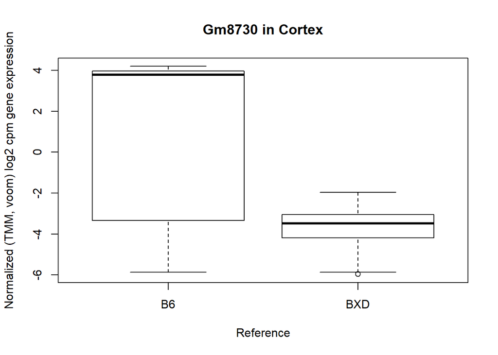

```
## $stats
##           [,1]      [,2]
## [1,] -5.872658 -5.874874
## [2,] -3.330432 -4.181812
## [3,]  3.791921 -3.482043
## [4,]  3.968937 -3.051470
## [5,]  4.193106 -1.961365
##
## $n
## [1] 66 66
##
## $conf
##          [,1]      [,2]
## [1,] 2.372307 -3.701877
## [2,] 5.211536 -3.262208
##
## $out
## [1] -5.962787
##
## $group
## [1] 2
##
## $names
## [1] "B6"  "BXD"
```

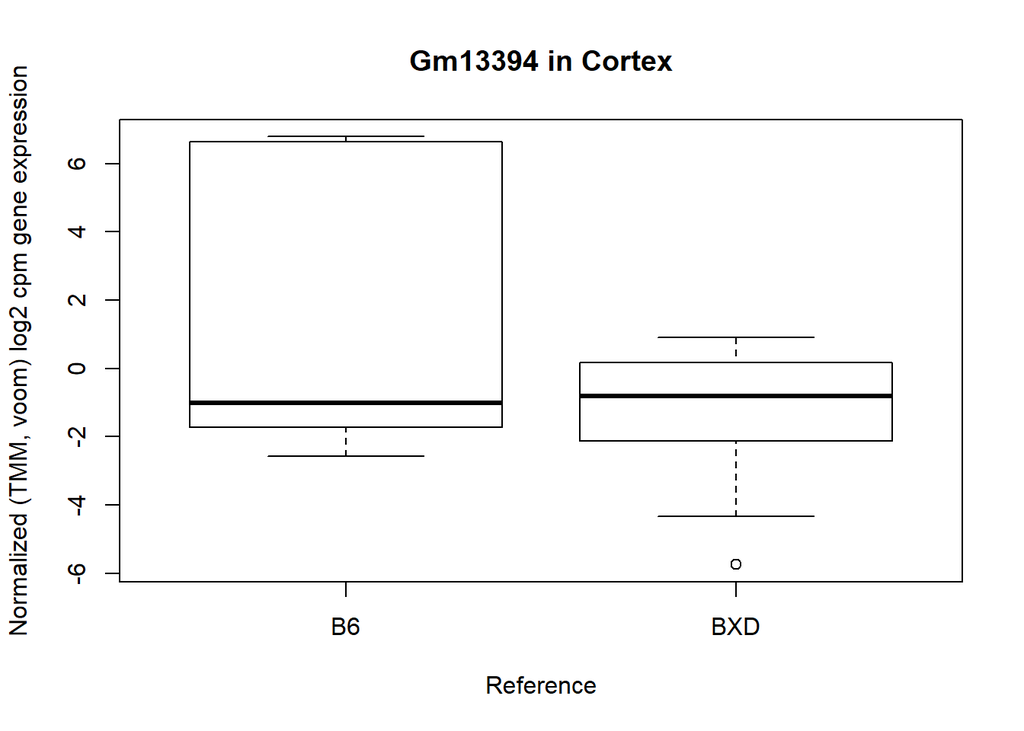

```
## $stats
##            [,1]       [,2]
## [1,] -2.5698628 -4.3321048
## [2,] -1.7139857 -2.1273231
## [3,] -0.9981366 -0.8111508
## [4,]  6.6474282  0.1680847
## [5,]  6.7895797  0.9001103
##
## $n
## [1] 66 66
##
## $conf
##            [,1]       [,2]
## [1,] -2.6243024 -1.2575722
## [2,]  0.6280293 -0.3647294
##
## $out
## [1] -5.741254
##
## $group
## [1] 2
##
## $names
## [1] "B6"  "BXD"
```

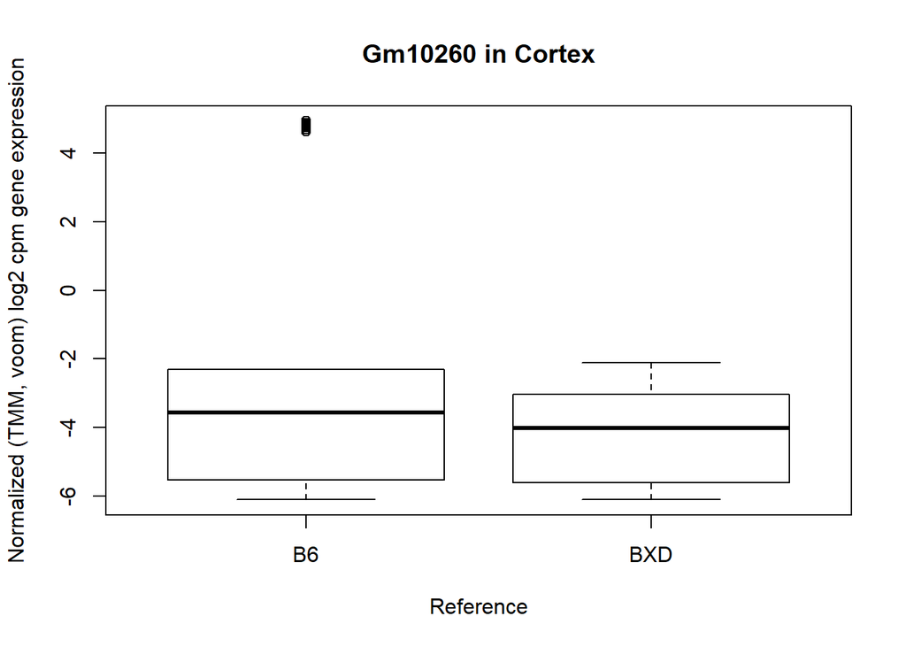

```
## $stats
##           [,1]      [,2]
## [1,] -6.106303 -6.108429
## [2,] -5.527891 -5.607915
## [3,] -3.570403 -4.011404
## [4,] -2.305084 -3.039038
## [5,] -2.305084 -2.116908
##
## $n
## [1] 66 66
##
## $conf
##           [,1]      [,2]
## [1,] -4.197189 -4.511010
## [2,] -2.943617 -3.511797
##
## $out
##  [1] 4.878821 4.749371 4.760372 4.820423 4.630618 4.776804 4.887945 4.791433
##  [9] 4.772390 4.881968 4.683629 4.827985 4.939158 4.791601 4.860470 4.830613
##
## $group
##  [1] 1 1 1 1 1 1 1 1 1 1 1 1 1 1 1 1
##
## $names
## [1] "B6"  "BXD"
```

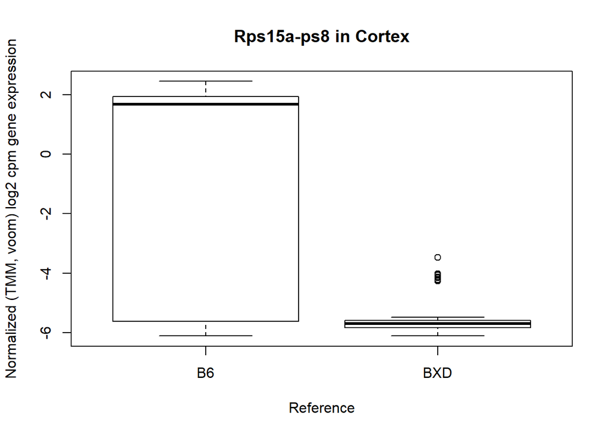

```
## $stats
##           [,1]      [,2]
## [1,] -6.106303 -6.108429
## [2,] -5.623133 -5.833192
## [3,]  1.680616 -5.699671
## [4,]  1.928242 -5.583487
## [5,]  2.443867 -5.485327
##
## $n
## [1] 66 66
##
## $conf
##           [,1]      [,2]
## [1,] 0.2119898 -5.748234
## [2,] 3.1492413 -5.651107
##
## $out
##  [1] -4.268436 -4.215948 -4.125980 -4.232386 -4.069169 -4.022952 -4.239993
##  [8] -4.133002 -4.268800 -3.469073 -4.034827 -4.072150 -4.156291
##
## $group
##  [1] 2 2 2 2 2 2 2 2 2 2 2 2 2
##
## $names
## [1] "B6"  "BXD"
```

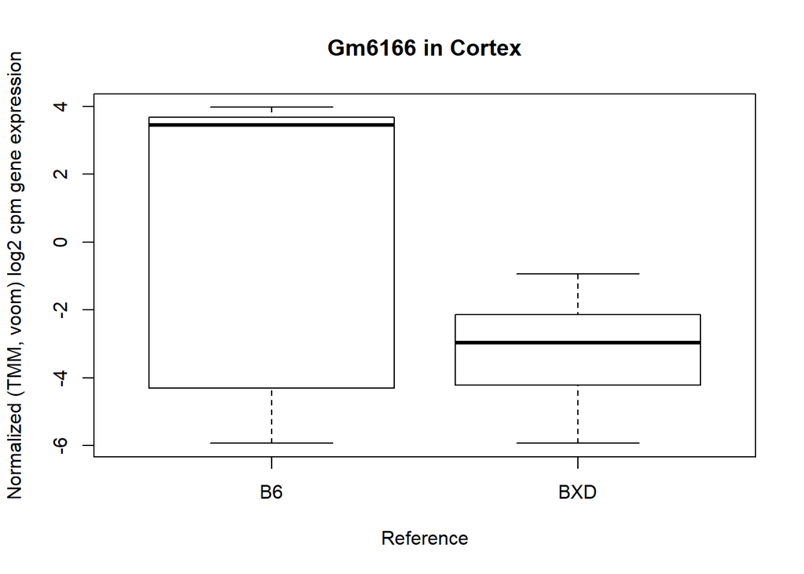

```
## $stats
##           [,1]      [,2]
## [1,] -5.926351 -5.928246
## [2,] -4.303573 -4.211686
## [3,]  3.462200 -2.971854
## [4,]  3.684831 -2.141937
## [5,]  3.974991 -0.931432
##
## $n
## [1] 66 66
##
## $conf
##          [,1]      [,2]
## [1,] 1.908579 -3.374388
## [2,] 5.015822 -2.569319
##
## $out
## numeric(0)
##
## $group
## numeric(0)
##
## $names
## [1] "B6"  "BXD"
```

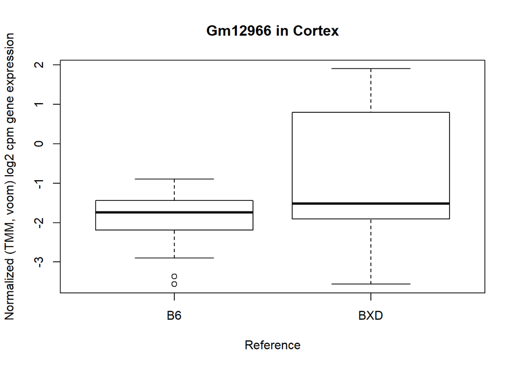

```
## $stats
##            [,1]       [,2]
## [1,] -2.8963722 -3.5616332
## [2,] -2.1929287 -1.9074752
## [3,] -1.7434208 -1.5229125
## [4,] -1.4421851  0.7942775
## [5,] -0.8940029  1.9000889
##
## $n
## [1] 66 66
##
## $conf
##           [,1]       [,2]
## [1,] -1.889429 -2.0483617
## [2,] -1.597413 -0.9974633
##
## $out
## [1] -3.369136 -3.560076
##
## $group
## [1] 1 1
##
## $names
## [1] "B6"  "BXD"
```

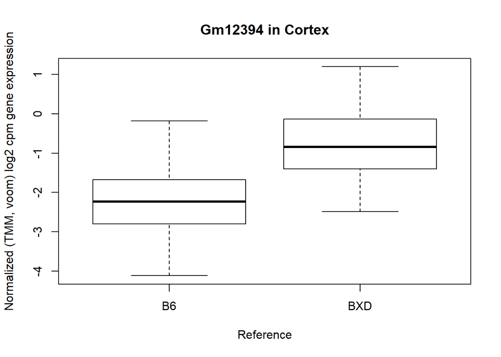

```
## $stats
##            [,1]       [,2]
## [1,] -4.1187646 -2.4871871
## [2,] -2.8007266 -1.3978646
## [3,] -2.2340621 -0.8405041
## [4,] -1.6770552 -0.1361780
## [5,] -0.1803771  1.1984048
##
## $n
## [1] 66 66
##
## $conf
##           [,1]       [,2]
## [1,] -2.452599 -1.0858827
## [2,] -2.015525 -0.5951256
##
## $out
## numeric(0)
##
## $group
## numeric(0)
##
## $names
## [1] "B6"  "BXD"
```

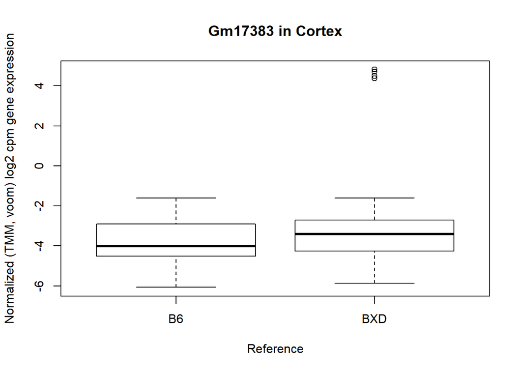

```
## $stats
##           [,1]      [,2]
## [1,] -6.069373 -5.873091
## [2,] -4.521341 -4.261431
## [3,] -4.009936 -3.414967
## [4,] -2.906783 -2.719912
## [5,] -1.616264 -1.617191
##
## $n
## [1] 66 66
##
## $conf
##           [,1]      [,2]
## [1,] -4.323942 -3.714769
## [2,] -3.695929 -3.115166
##
## $out
## [1] 4.698207 4.493587 4.814584 4.377526
##
## $group
## [1] 2 2 2 2
##
## $names
## [1] "B6"  "BXD"
```

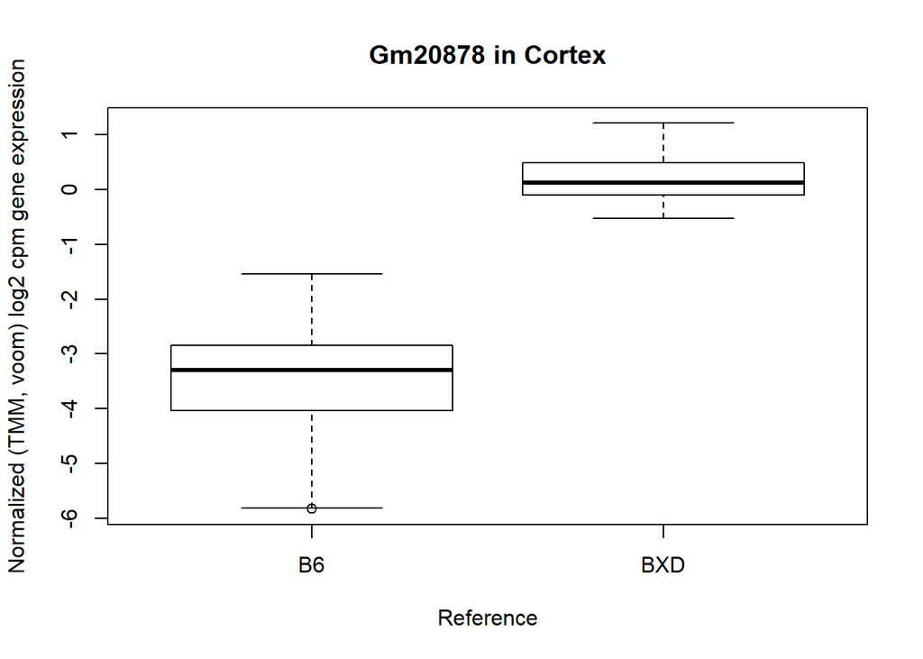

```
## $stats
##           [,1]       [,2]
## [1,] -5.815094 -0.5322845
## [2,] -4.033198 -0.1009463
## [3,] -3.291831  0.1197341
## [4,] -2.843072  0.4826019
## [5,] -1.535670  1.2085598
##
## $n
## [1] 66 66
##
## $conf
##           [,1]       [,2]
## [1,] -3.523292 0.00624295
## [2,] -3.060370 0.23322518
##
## $out
## [1] -5.826724
##
## $group
## [1] 1
##
## $names
## [1] "B6"  "BXD"
```

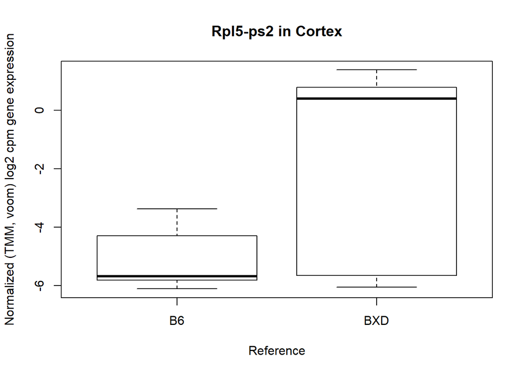

```
## $stats
##           [,1]       [,2]
## [1,] -6.106303 -6.0488281
## [2,] -5.814973 -5.6518770
## [3,] -5.673739  0.4011363
## [4,] -4.287695  0.7834585
## [5,] -3.368185  1.3818352
##
## $n
## [1] 66 66
##
## $conf
##           [,1]       [,2]
## [1,] -5.970771 -0.8504371
## [2,] -5.376707  1.6527096
##
## $out
## numeric(0)
##
## $group
## numeric(0)
##
## $names
## [1] "B6"  "BXD"
```

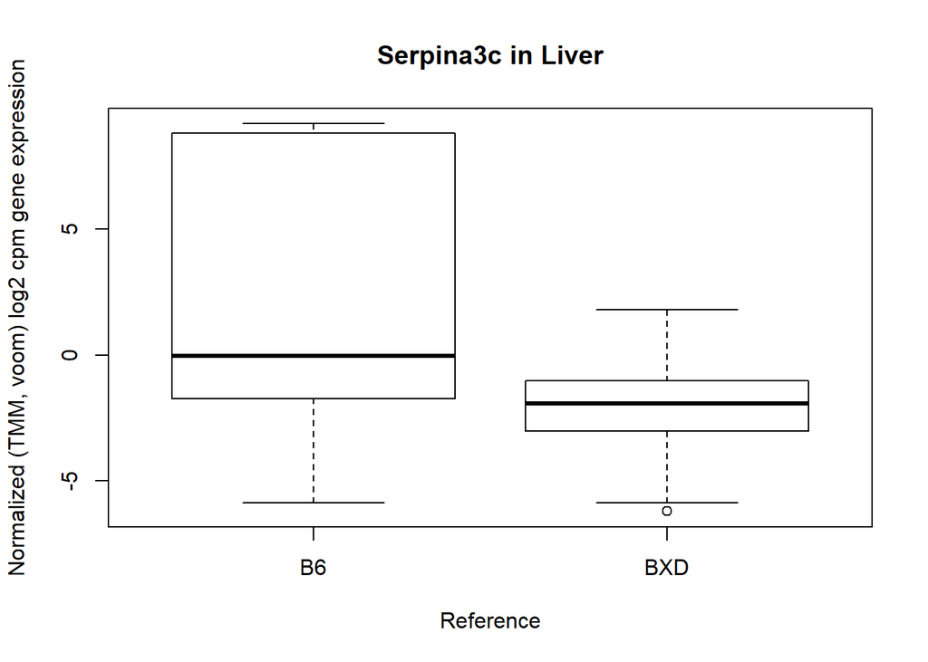

```
## $stats
##             [,1]      [,2]
## [1,] -5.87446325 -5.876174
## [2,] -1.72509765 -3.023518
## [3,] -0.04109231 -1.935295
## [4,]  8.80880302 -1.007287
## [5,]  9.19342429  1.805535
##
## $n
## [1] 66 66
##
## $conf
##           [,1]      [,2]
## [1,] -2.089773 -2.327421
## [2,]  2.007589 -1.543169
##
## $out
## [1] -6.20691
##
## $group
## [1] 2
##
## $names
## [1] "B6"  "BXD"
```

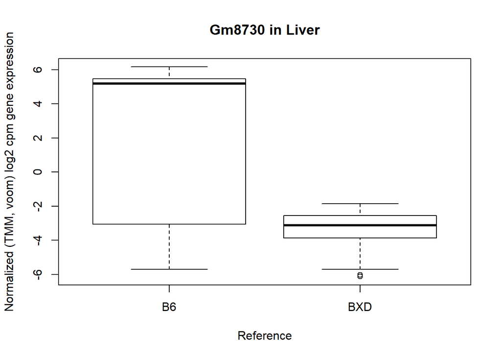

```
## $stats
##           [,1]      [,2]
## [1,] -5.695011 -5.696720
## [2,] -3.065315 -3.876359
## [3,]  5.195197 -3.112802
## [4,]  5.461836 -2.550635
## [5,]  6.160402 -1.845964
##
## $n
## [1] 66 66
##
## $conf
##          [,1]      [,2]
## [1,] 3.536798 -3.370634
## [2,] 6.853596 -2.854969
##
## $out
## [1] -6.123385 -6.032400
##
## $group
## [1] 2 2
##
## $names
## [1] "B6"  "BXD"
```

[8 more figures not shown]

```
## $stats
##           [,1]      [,2]
## [1,] -6.393800 -6.395949
## [2,] -5.912522 -5.595475
## [3,] -5.657838  2.346074
## [4,] -4.325026  2.690350
## [5,] -2.413238  3.643630
##
## $n
## [1] 66 66
##
## $conf
##           [,1]      [,2]
## [1,] -5.966581 0.7346084
## [2,] -5.349094 3.9575386
##
## $out
## numeric(0)
##
## $group
## numeric(0)
##
## $names
## [1] "B6"  "BXD"
```

```r
for (mytissue in c("Cortex","Liver")){
  completelist <- rownames(get(paste("DMdata_", mytissue, sep="")))
  for (mygene in c(head(completelist, 5), tail(completelist, 5))){
    print(boxplot(as.numeric(get(paste("res", mytissue, "Norm", sep=""))[mygene,]) ~ factor(variables[, "mappingref"]), main=paste(mygene, "in", mytissue), xlab="Reference", ylab="Normalized (TMM, voom) log2 cpm gene expression"))
  }
}
```

```r
# how many have a log fold change (absolute value) above 2?
length(which(abs(DMdata_Cortex$logFC)>2))
```

```
## [1] 54
```

```r
length(which(abs(DMdata_Liver$logFC)>2))
```

```
## [1] 59
```